# Gathering and Manipulation of Unstructured Data

March 28, 2018

## Structured vs Unstractured data

- Structured
  - data table
  - example: excel, html table
  - tools: SQL, R, excel
- Semi structured
  - xml, json
  - example: some specific web
  - tools: R package `rvest`, `rjson`
- Unstructured
  - plain text
  - example: twitter, web sites
  - tools: R package `stringr`, `twitteR`

## Gathering data from web

- method 1: scrap raw text data
  - clean and analyse
- method 2: xml or json data
- method 3: use API
  - twitter, facebook, weather data

## method 1: Scraping raw html data

```r
# install.packages("rvest")
library(rvest)
w <- read_html("https://www.firstnational.com/")
html_text(w)
```

```
## [1] "First National Bank of Omaha | Personal & Business Banking and Insights \n  \n   \n   \n     \r\nJavascript must be enabled for the correct page display\r\nSkip to Content\r\n\r\nX\r\n\r\n          We're currently redesigning our website to better serve you! Thank you for your patience durin…
```

```r
site <- read_html("http://mamajumder.github.io/index.html")
site %>%
  html_nodes("div p") %>%
  html_text()
```

```
## [1] "Mathematics"
## [2] "Mahbubul Majumder, PhD \n\tAssistant Professor \n\tDepartment of Mathematics \n\t238 Durham Science Center  \n\tUniv. of Nebraska at Omaha mmajumder@unomaha.edu\n\tPhone: (402) 554-2734 \n\tFax: (402) 554-2975 "
## [3] " This is the web site of Mahbubul Majumder. I am an Assistant Professor of statistics in the department of Mathematics, University of Nebraska at Omaha (UNO). My academic training is in statistics with specialization in data visualization and visual statistical inference. Before getting to t…
```

## method 2: data as html or xml

- Data can be hidden in html
  - html tag
  - tag attribute
  - html text
- To glean data
  - locate the data by inspection
  - find if it is html tag or attribute or text
  - obtain the path using google chrome

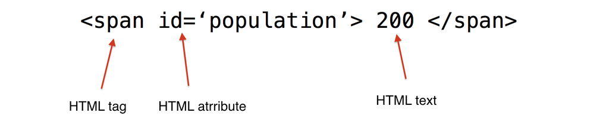

## understanding xml path

- Using google chrome visit the web site to gather data from
  - right click >> inspect
  - right click on the object that contains the data >> copy xpath
- Demonstration of gathering Nebraska population data from https://www.nebraska-demographics.com/cities_by_population

## Scraping html table

```r
wPop <- read_html("https://www.nebraska-demographics.com/cities_by_population")
dat <- wPop %>%
  html_nodes(xpath='/html/body/div[3]/div[2]/table') %>%
  html_table()
D <- dat[[1]]
head(D)
```

```
##   Nebraska Cities by Population Rank         City Population
## 1                                  1        Omaha    446,970
## 2                                  2      Lincoln    280,364
## 3                                  3     Bellevue     53,505
## 4                                  4 Grand Island     51,517
## 5                                  5      Kearney     33,520
## 6                                  6      Fremont     26,519
```

## Scraping html text

```r
movie_titanic <- read_html("http://www.imdb.com/title/tt0120338/")
html_nodes(movie_titanic, css="strong span")
```

```
## {xml_nodeset (1)}
## [1] <span itemprop="ratingValue">7.8</span>
```

```r
rating <- movie_titanic %>%
  html_nodes("strong span") %>%
  html_text() %>%
  as.numeric()
rating
```

```
## [1] 7.8
```

## Scraping html attribute

```r
url <- "https://www.firstnational.com/site/about-us"
location_map <- read_html(url)
map <- location_map %>%
  html_nodes(xpath = '//*[@id="section3"]/div/div[2]/div[6]/img') %>%
  html_attr('src')
knitr::include_graphics(paste0("https://www.firstnational.com",map))
```

[figure not shown]

## method 3: Scraping data using API

- Some web applications provide API so that end users can access data they provide
- We will show how to get data from tweeter using their API
- Use `R` package `twitteR` to extract and work with twitter data
  - you can search specific tweets by person, location, topic etc.
  - analyse re-tweets, counts etc.
  - install `twitteR` from `github` not `CRAN` what you usually do
  - for details visit https://github.com/geoffjentry/twitteR/

```r
# install.packages(c("devtools", "rjson", "bit64", "httr", "base64enc"))
# library(devtools)
# install_github("geoffjentry/twitteR")
```

## Setting up twitter API

- First create a twitter account
- create a new application from https://apps.twitter.com/
- will provide you with API keys and secrets
- Now run the following codes from `R`

```r
library(twitteR)

api_key <- "your api key"
api_secret <- "your api secret"
access_token <- "your access tocken"
access_token_secret <- "your access tocken secret"

setup_twitter_oauth(api_key,api_secret,access_token,
                    access_token_secret)
```

```
## [1] "Using direct authentication"
```

## Case Study: Getting the tweets about data science

```r
dsTweet <- searchTwitter("data science")
dfTweet <- twListToDF(dsTweet)
tweetText <- dfTweet$text
head(tweetText)
```

```
## [1] "RT @random_walker: Tech buzzwords explained:\nAI—regression\nBig data—data\nBlockchain—database\nAlgorithm—automated decision-making\nCloud—Inte…"
## [2] "The Data-Driven Public Library: Marketing Science Meets Art New Jersey State Library https://t.co/R7cJl9mGH6 https://t.co/w2OUnmccm9"
## [3] "My first science article was an introductory one highlighting the importance of open source approach in Science. Li… https://t.co/FLWOBeMfdV"
## [4] "RT @mog7546: NEW\n\nIt's not just Facebook -- here’s how the #Mercer pro-Trump data firm Cambridge Analytica WEAPONIZED #AMAZON\n\nOffer to pay…"
## [5] "RT @IainLJBrown: MapR to Present on Data Science, Machine Learning and IoT Data Strategies at Upcoming Spring Conferences #DataScience #Mac…"
## [6] "RT @DanGraur: To all the morons who wrote eulogies to #junkDNA (e.g., @ENCODE_NIH, @NIHDirector, @ewanbirney), kindly bow and genuflect to…"
```

## Case Study: tweets of Justin Bieber

```r
user <- getUser("justinbieber")
jb <- userTimeline(user, n=500)
snDf <- twListToDF(jb)
snText <- snDf$text
library(stringr)
snWords <- str_extract_all(snText, '(\\w+)')
head(snWords)
```

```
## [[1]]
## [1] "Grateful" "for"      "great"    "friends"
##
## [[2]]
## [1] "Proud"      "of"         "these"      "kids"       "https"
## [6] "t"          "co"         "M796VNgWWV"
##
## [[3]]
## [1] "This"       "is"         "great"      "https"      "t"
## [6] "co"         "53KZ5720Tw"
##
## [[4]]
## [1] "24"
##
## [[5]]
##  [1] "Cameron"    "good"       "talking"    "to"         "you"
##  [6] "last"       "night"      "All"        "of"         "your"
## [11] "bravery"    "is"         "amazing"    "I"          "stand"
## [16] "with"       "you"        "guys"       "march24"    "https"
## [21] "t"          "co"         "FnSUpgJFgx"
##
## [[6]]
## [1] "JerrySeinfeld" "I"             "told"          "you"
## [5] "it"            "was"           "me"
```

## Case Study: Hashtags in JB's tweets

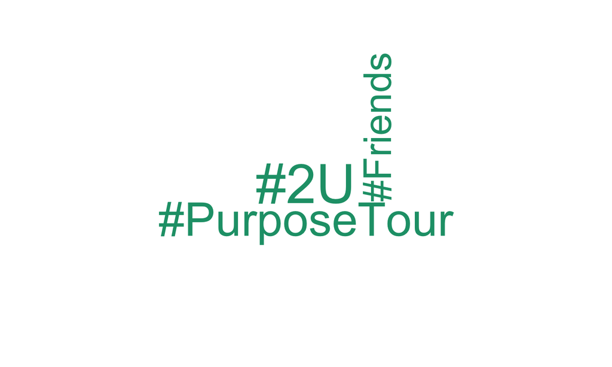

```r
snHashtags = str_extract_all(snDf$text, "#\\w+")
freq <- table(unlist(snHashtags))

library(wordcloud)
wordcloud(names(freq), freq, random.order=FALSE, colors="#1B9E77")
```

## Sources of tweets

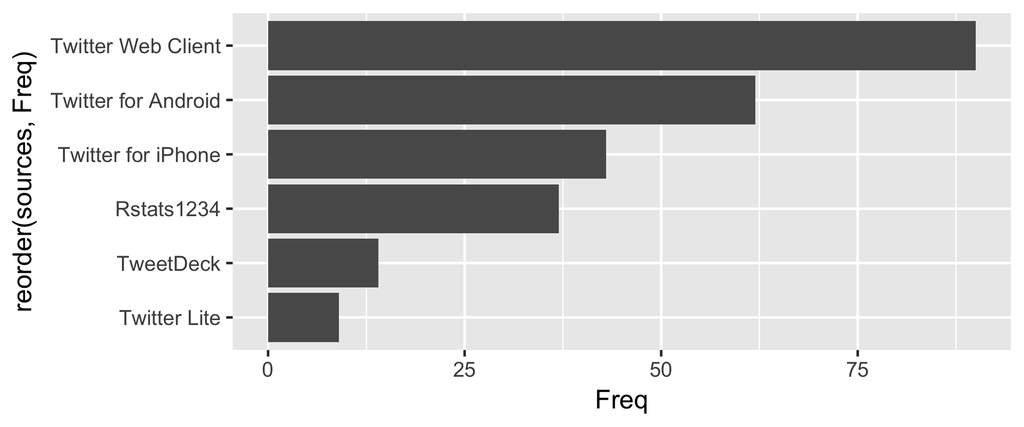

```r
r_tweets <- searchTwitter("#rstats", n=300)
sources <- sapply(r_tweets, function(x) x$getStatusSource())
sources <- gsub("</a>", "", sources)
sources <- strsplit(sources, ">")
sources <- sapply(sources, function(x) ifelse(length(x) > 1, x[2], x[1]))
source_table = table(sources)
df <- data.frame(names(source_table),source_table)
library(ggplot2)
ggplot(df[df$Freq>8,], aes(reorder(sources,Freq),Freq)) +
  geom_bar(stat="identity") + coord_flip()
```

## References

- Read chapter 4 of [*Modern Data Science with R*](https://www.crcpress.com/Modern-Data-Science-with-R/Baumer-Kaplan-Horton/p/book/9781498724487) by Baumer et. al.
- For details about setting up `twitteR` package in `R`  
  https://github.com/geoffjentry/twitteR/
- For examples of `twitteR` functions and what this package can deliver visit  
  http://geoffjentry.hexdump.org/twitteR.pdf
- For examples of `rvest` functions and what this package can deliver visit  
  https://blog.rstudio.com/2014/11/24/rvest-easy-web-scraping-with-r/